# Lab 2 Homework

Caijun Qin

01/29/2021

**This homework is due on Friday, January 29 2021. Please show all your work and justify your answers.**

1. Create a numerical summary for `height` and `age`, compute the interquartile range for each. Compute the relative frequency distribution for `gender` and `exerany`. How many males are in the sample? What proportion of the sample reports being in excellent health?

Resp: The IQR for `height` and `age` are 6 and 26, respectively. The relative frequencies for `gender` and `exerany` are given as single-row tables. There are 9569 males in the sample. The proportion of the sample with “excellent” health in `genhlth` is 0.23285.

```r
source("http://www.openintro.org/stat/data/cdc.R")

print(head(x = cdc, n = 10))
```

```
##      genhlth exerany hlthplan smoke100 height weight wtdesire age gender
## 1       good       0        1        0     70    175      175  77      m
## 2       good       0        1        1     64    125      115  33      f
## 3       good       1        1        1     60    105      105  49      f
## 4       good       1        1        0     66    132      124  42      f
## 5  very good       0        1        0     61    150      130  55      f
## 6  very good       1        1        0     64    114      114  55      f
## 7  very good       1        1        0     71    194      185  31      m
## 8  very good       0        1        0     67    170      160  45      m
## 9       good       0        1        1     65    150      130  27      f
## 10      good       1        1        0     70    180      170  44      m
```

```r
summary(object = cdc)
```

```
##       genhlth        exerany          hlthplan         smoke100
##  excellent:4657   Min.   :0.0000   Min.   :0.0000   Min.   :0.0000
##  very good:6972   1st Qu.:0.0000   1st Qu.:1.0000   1st Qu.:0.0000
##  good     :5675   Median :1.0000   Median :1.0000   Median :0.0000
##  fair     :2019   Mean   :0.7457   Mean   :0.8738   Mean   :0.4721
##  poor     : 677   3rd Qu.:1.0000   3rd Qu.:1.0000   3rd Qu.:1.0000
##                   Max.   :1.0000   Max.   :1.0000   Max.   :1.0000
##      height          weight         wtdesire          age        gender
##  Min.   :48.00   Min.   : 68.0   Min.   : 68.0   Min.   :18.00   m: 9569
##  1st Qu.:64.00   1st Qu.:140.0   1st Qu.:130.0   1st Qu.:31.00   f:10431
##  Median :67.00   Median :165.0   Median :150.0   Median :43.00
##  Mean   :67.18   Mean   :169.7   Mean   :155.1   Mean   :45.07
##  3rd Qu.:70.00   3rd Qu.:190.0   3rd Qu.:175.0   3rd Qu.:57.00
##  Max.   :93.00   Max.   :500.0   Max.   :680.0   Max.   :99.00
```

```r
# IQR
height_quantiles <-quantile(x = cdc$height)
age_quantiles <- quantile(x = cdc$age)
print("height quantiles:")
```

```
## [1] "height quantiles:"
```

```r
print(height_quantiles)
```

```
##   0%  25%  50%  75% 100%
##   48   64   67   70   93
```

```r
print("age_quantiles:")
```

```
## [1] "age_quantiles:"
```

```r
print(age_quantiles)
```

```
##   0%  25%  50%  75% 100%
##   18   31   43   57   99
```

```r
height_iqr <- IQR(x = cdc$height)
age_iqr <- IQR(x = cdc$age)
sprintf("height IQR: %f", height_iqr)
```

```
## [1] "height IQR: 6.000000"
```

```r
sprintf("age IQR: %f", age_iqr)
```

```
## [1] "age IQR: 26.000000"
```

```r
assertthat::are_equal(as.numeric(x = height_quantiles[4] - height_quantiles[2]), height_iqr)
```

```
## [1] TRUE
```

```r
assertthat::are_equal(as.numeric(x = age_quantiles[4] - age_quantiles[2]), age_iqr)
```

```
## [1] TRUE
```

```r
# Relative Frequency Distribution
gender_table = table(cdc$gender)
cat("\ntable of frequencies for gender:")
```

```
##
## table of frequencies for gender:
```

```r
print(gender_table)
```

```
##
##     m     f
##  9569 10431
```

```r
gender_rel_freq <- gender_table / length(x = cdc$gender)
cat("\ntable of relative frequencies for gender:")
```

```
##
## table of relative frequencies for gender:
```

```r
print(gender_rel_freq)
```

```
##
##       m       f
## 0.47845 0.52155
```

```r
exerany_table = table(cdc$exerany)
cat("\ntable of frequencies for exerany:")
```

```
##
## table of frequencies for exerany:
```

```r
print(exerany_table)
```

```
##
##     0     1
##  5086 14914
```

```r
exerany_rel_freq <- exerany_table / length(x = cdc$exerany)
cat("\ntable of relative frequencies for exerany:")
```

```
##
## table of relative frequencies for exerany:
```

```r
print(exerany_rel_freq)
```

```
##
##      0      1
## 0.2543 0.7457
```

```r
# Males in sample
cat("\nNumber of males in sample: ", gender_table["m"])
```

```
##
## Number of males in sample:  9569
```

```r
# Genhealth statistics
cat("\nlevels of genhealth:")
```

```
##
## levels of genhealth:
```

```r
print(levels(x = cdc$genhlth))
```

```
## [1] "excellent" "very good" "good"      "fair"      "poor"
```

```r
genhealth_table <- table(cdc$genhlth)
cat("\ntable of frequencies for genhealth:")
```

```
##
## table of frequencies for genhealth:
```

```r
print(genhealth_table)
```

```
##
## excellent very good      good      fair      poor
##      4657      6972      5675      2019       677
```

```r
cat("\nProportion having excellent health in sample: ", genhealth_table["excellent"] / length(cdc$genhlth))
```

```
##
## Proportion having excellent health in sample:  0.23285
```

2. What does the following mosaic plot reveal about smoking habits and gender?

Resp: The mosaic plot shows that overall, approximately half of people for each gender smokes. Males smoke only slightly more than females relative to all observations within the same gender.

```r
gender_smoke_tb <- table(cdc$gender,cdc$smoke100)
mosaicplot(gender_smoke_tb)
```

[output not shown]

3. What does the following box plot of BMI vs general health show? Pick another categorical variable from the data set and see how it relates to BMI. List the variable you chose, why you might think it would have a relationship to BMI, and indicate what the figure seems to suggest.

Resp: The first boxplot shows that as the ordinal rank, as ordered in the sequence of x-labels, is closer to excellent, then `bmi` is lower on average. For this same trend, the variance of `bmi` also shrinks as the general health status is closer to excellent, as visually illustrated by the IQR gap. Another interesting variable to compare to `bmi` is `age`. Since physiology and overall health changes between age groups, this might be a meaningful factor in determining `bmi`. For the corresponding boxplot, `bmi` means (averages) across `age` are roughly constant inside the 20-25 interval. More so than `bmi` vs. `genhlth`, the outliers on the upper end of the boxplot have far greater variance and range. This seems to suggest that `bmi` could vary drastically in a high interval but barely for low values.

```r
print(head(x = cdc, n = 10))
bmi <- (cdc$weight / cdc$height^2) * 703
boxplot(bmi ~ cdc$genhlth)
boxplot(bmi ~ cdc$age, xlab = "age")
```

[output not shown]

4. Make a scatterplot of weight versus desired weight. Describe the relationship between these two variables.

Resp: The relationship between the two variables is roughly positively linear. As desired weight (`wtdesire`) increases, the actual weight (`weight`) also tends to increase. The strength of the relationship, measured by correlation coefficient, is about 0.8.

```r
# Include your code here

print(head(x = cdc, n = 10))
```

```
##      genhlth exerany hlthplan smoke100 height weight wtdesire age gender
## 1       good       0        1        0     70    175      175  77      m
## 2       good       0        1        1     64    125      115  33      f
## 3       good       1        1        1     60    105      105  49      f
## 4       good       1        1        0     66    132      124  42      f
## 5  very good       0        1        0     61    150      130  55      f
## 6  very good       1        1        0     64    114      114  55      f
## 7  very good       1        1        0     71    194      185  31      m
## 8  very good       0        1        0     67    170      160  45      m
## 9       good       0        1        1     65    150      130  27      f
## 10      good       1        1        0     70    180      170  44      m
```

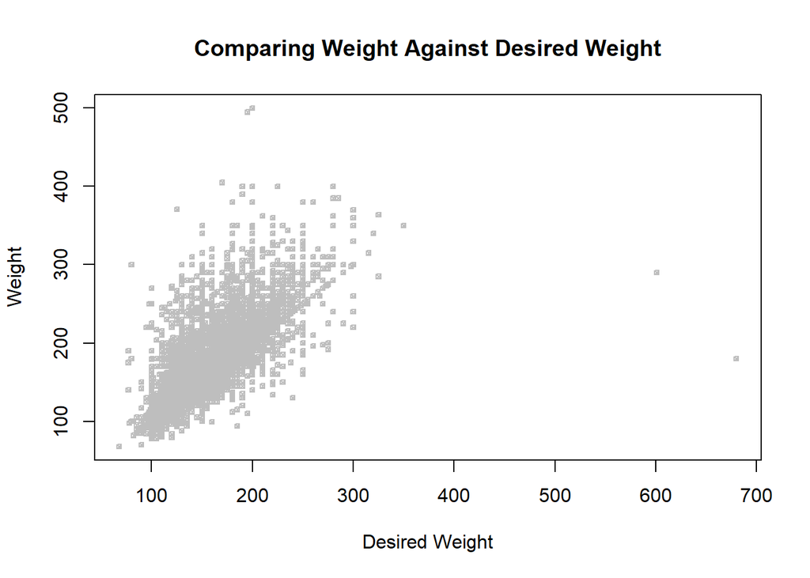

```r
plot(x =cdc$wtdesire,  y = cdc$weight, col = "gray", cex = 0.5, pch = 7, main = "Comparing Weight Against Desired Weight", xlab = "Desired Weight", ylab = "Weight")
```

```r
sprintf("Correlation coefficient: %f", cor(x = cdc$wtdesire, y = cdc$weight))
```

```
## [1] "Correlation coefficient: 0.800052"
```

5. Let’s consider a new variable: the difference between desired weight (`wtdesire`) and current weight (`weight`). Create this new variable by subtracting the two columns in the data frame and assigning them to a new object called `wdiff`.

Resp:

```r
# Include your code here
print(head(x = cdc, n = 10))
```

```
##      genhlth exerany hlthplan smoke100 height weight wtdesire age gender
## 1       good       0        1        0     70    175      175  77      m
## 2       good       0        1        1     64    125      115  33      f
## 3       good       1        1        1     60    105      105  49      f
## 4       good       1        1        0     66    132      124  42      f
## 5  very good       0        1        0     61    150      130  55      f
## 6  very good       1        1        0     64    114      114  55      f
## 7  very good       1        1        0     71    194      185  31      m
## 8  very good       0        1        0     67    170      160  45      m
## 9       good       0        1        1     65    150      130  27      f
## 10      good       1        1        0     70    180      170  44      m
```

```r
wdiff <- cdc$wtdesire - cdc$weight
cat("wdiff data type: ", typeof(x = wdiff))
```

```
## wdiff data type:  integer
```

```r
cat("\n", is(object = wdiff, class2 = "vector"))
```

```
##
##  TRUE
```

```r
cat("\nis vector? ", is.vector(x = wdiff))
```

```
##
## is vector?  TRUE
```

```r
cat("\nis list? ", is.list(x = wdiff))
```

```
##
## is list?  FALSE
```

```r
cat("\nis array? ", is.array(x = wdiff))
```

```
##
## is array?  FALSE
```

```r
cat("\nwdiff dimensions: ", dim(x = wdiff))
```

```
##
## wdiff dimensions:
```

```r
cat("\nwdiff (first 10):\n", wdiff[1:10])
```

```
##
## wdiff (first 10):
##  0 -10 0 -8 -20 0 -9 -10 -20 -10
```

6. What type of data is `wdiff`? If an observation `wdiff` is 0, what does this mean about the person`s weight and desired weight. What if`whiff` is positive or negative?

Resp: `wdiff` is a vector of integer elements. A value of 0 in `wdiff` means that the corresponding `weight` and `wtdesired` values are exactly equal. In context, this means any person with a difference of 0 between the desired weight and weight has already achieved the desired goal for weight. A positive value, mathematically having `wtdesired` > `weight`, means that such a person actually has a lower weight currently than his or her target weight. For a negative value, `wtdesired` < `weight` holds true, indicating that such a person has to lose more weight to reach his or her desired weight.

7. Describe the shape of the distribution of `wdiff` include any plots you use. What does this tell us about how people feel about their current weight?

```r
# Include your code here
print(head(x = cdc, n = 10))
```

```
##      genhlth exerany hlthplan smoke100 height weight wtdesire age gender
## 1       good       0        1        0     70    175      175  77      m
## 2       good       0        1        1     64    125      115  33      f
## 3       good       1        1        1     60    105      105  49      f
## 4       good       1        1        0     66    132      124  42      f
## 5  very good       0        1        0     61    150      130  55      f
## 6  very good       1        1        0     64    114      114  55      f
## 7  very good       1        1        0     71    194      185  31      m
## 8  very good       0        1        0     67    170      160  45      m
## 9       good       0        1        1     65    150      130  27      f
## 10      good       1        1        0     70    180      170  44      m
```

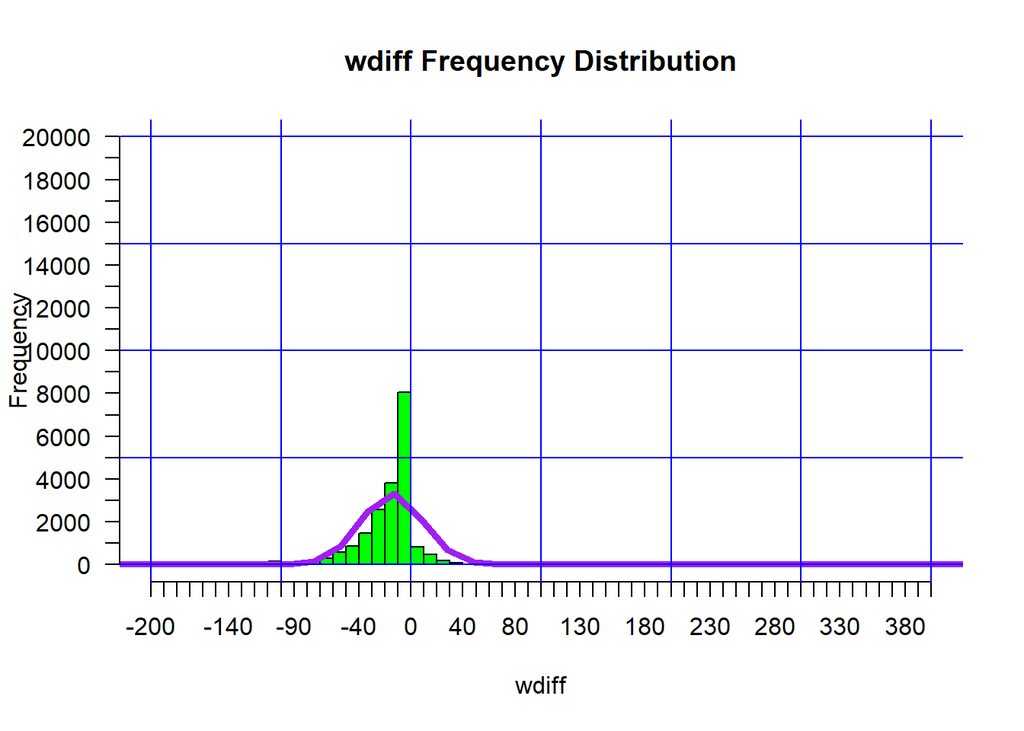

```r
wdiff_hist <- hist(x = wdiff, breaks = 100, axes = FALSE, xaxt = "n", yaxt = "n", xlim = c(-200, 400),
                   ylim = c(0, 20000), col = "green", labels = FALSE, main = "wdiff Frequency Distribution")

# Applying approximated normal curve
xfit <- seq(min(wdiff), max(wdiff), length = 40)
yfit <- dnorm(x = xfit, mean = mean(wdiff), sd = sd(wdiff)) * diff(wdiff_hist$mids[1:2]) * length(wdiff)
lines(x = xfit, y = yfit, col = "purple", lwd = 4)

# Axis and grid changes
axis(side = 1, at = seq(-200, 400, by = 10), las = 1)
axis(side = 2, at = seq(0, 20000, by = 1000), las = 2)
grid(col = "blue", lty = 1)
```

```r
# Computing statistics
summary(object = wdiff)
```

```
##    Min. 1st Qu.  Median    Mean 3rd Qu.    Max.
## -300.00  -21.00  -10.00  -14.59    0.00  500.00
```

```r
sprintf("variance of wdiff: %f", var(x = wdiff))
```

```
## [1] "variance of wdiff: 578.203171"
```

```r
sprintf("standard deviation of wdiff: %f", sd(x = wdiff))
```

```
## [1] "standard deviation of wdiff: 24.045856"
```

8. Using numerical summaries and a side-by-side box plot, determine if men tend to view their weight differently than women. Explain.

```r
# Include your code here
print(head(x = cdc, n = 10))
```

```
##      genhlth exerany hlthplan smoke100 height weight wtdesire age gender
## 1       good       0        1        0     70    175      175  77      m
## 2       good       0        1        1     64    125      115  33      f
## 3       good       1        1        1     60    105      105  49      f
## 4       good       1        1        0     66    132      124  42      f
## 5  very good       0        1        0     61    150      130  55      f
## 6  very good       1        1        0     64    114      114  55      f
## 7  very good       1        1        0     71    194      185  31      m
## 8  very good       0        1        0     67    170      160  45      m
## 9       good       0        1        1     65    150      130  27      f
## 10      good       1        1        0     70    180      170  44      m
```

```r
wdiff_m <- wdiff[cdc$gender == "m"]
wdiff_f <- wdiff[cdc$gender == "f"]
cat("\n wdiff summary statistics for males: \n")
```

```
##
##  wdiff summary statistics for males:
```

```r
print(summary(wdiff_m))
```

```
##    Min. 1st Qu.  Median    Mean 3rd Qu.    Max.
## -300.00  -20.00   -5.00  -10.71    0.00  500.00
```

```r
cat("\n wdiff summary statistics for females: \n")
```

```
##
##  wdiff summary statistics for females:
```

```r
print(summary(wdiff_f))
```

```
##    Min. 1st Qu.  Median    Mean 3rd Qu.    Max.
## -300.00  -27.00  -10.00  -18.15    0.00   83.00
```

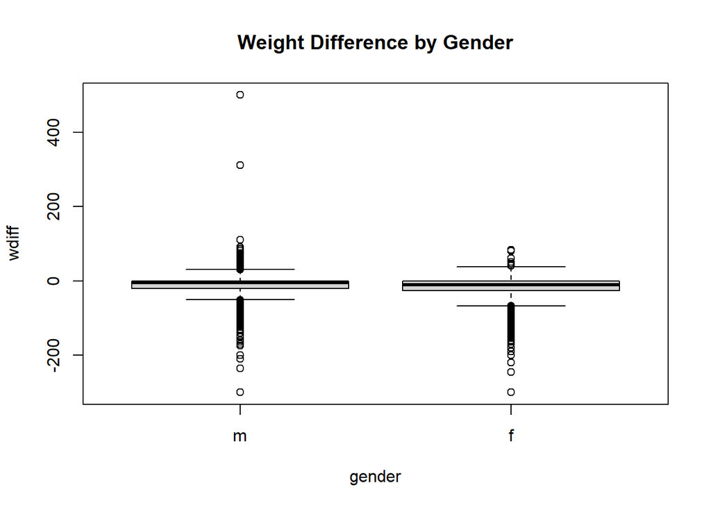

```r
boxplot(wdiff ~ cdc$gender, xlab = "gender", main = "Weight Difference by Gender")
```

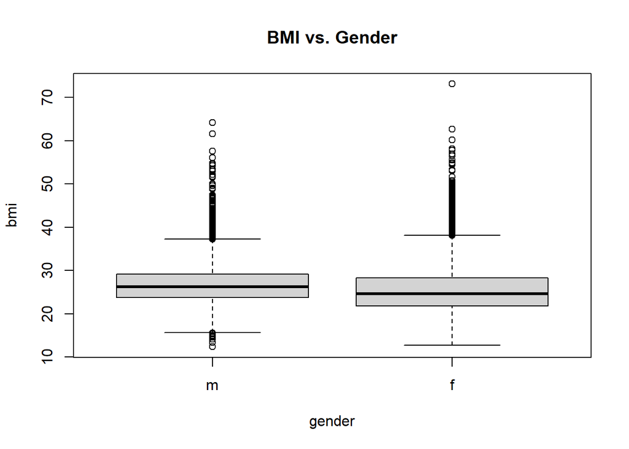

```r
bmi <- (cdc$weight / cdc$height^2) * 703
boxplot(bmi ~ cdc$gender, xlab = "gender", main = "BMI vs. Gender")
```